# What Makes High Quality White Wine?

# Introduction

This analysis use the white wine datasets, which include objective tests (e.g. PH values) and sensory data (grade by wine experts), to study the features of high graded white wine.

The dataset is from: P. Cortez, A. Cerdeira, F. Almeida, T. Matos and J. Reis. Modeling wine preferences by data mining from physicochemical properties. In Decision Support Systems, Elsevier, 47(4):547-553. ISSN: 0167-9236.

# Univariate Plots Section

A quick look at the dimension and structure of the data.

```
## 'data.frame':    4898 obs. of  13 variables:
##  $ X                   : int  1 2 3 4 5 6 7 8 9 10 ...
##  $ fixed.acidity       : num  7 6.3 8.1 7.2 7.2 8.1 6.2 7 6.3 8.1 ...
##  $ volatile.acidity    : num  0.27 0.3 0.28 0.23 0.23 0.28 0.32 0.27 0.3 0.22 ...
##  $ citric.acid         : num  0.36 0.34 0.4 0.32 0.32 0.4 0.16 0.36 0.34 0.43 ...
##  $ residual.sugar      : num  20.7 1.6 6.9 8.5 8.5 6.9 7 20.7 1.6 1.5 ...
##  $ chlorides           : num  0.045 0.049 0.05 0.058 0.058 0.05 0.045 0.045 0.049 0.044 ...
##  $ free.sulfur.dioxide : num  45 14 30 47 47 30 30 45 14 28 ...
##  $ total.sulfur.dioxide: num  170 132 97 186 186 97 136 170 132 129 ...
##  $ density             : num  1.001 0.994 0.995 0.996 0.996 ...
##  $ pH                  : num  3 3.3 3.26 3.19 3.19 3.26 3.18 3 3.3 3.22 ...
##  $ sulphates           : num  0.45 0.49 0.44 0.4 0.4 0.44 0.47 0.45 0.49 0.45 ...
##  $ alcohol             : num  8.8 9.5 10.1 9.9 9.9 10.1 9.6 8.8 9.5 11 ...
##  $ quality             : int  6 6 6 6 6 6 6 6 6 6 ...
```

```
##        X        fixed.acidity    volatile.acidity  citric.acid
##  Min.   :   1   Min.   : 3.800   Min.   :0.0800   Min.   :0.0000
##  1st Qu.:1225   1st Qu.: 6.300   1st Qu.:0.2100   1st Qu.:0.2700
##  Median :2450   Median : 6.800   Median :0.2600   Median :0.3200
##  Mean   :2450   Mean   : 6.855   Mean   :0.2782   Mean   :0.3342
##  3rd Qu.:3674   3rd Qu.: 7.300   3rd Qu.:0.3200   3rd Qu.:0.3900
##  Max.   :4898   Max.   :14.200   Max.   :1.1000   Max.   :1.6600
##  residual.sugar     chlorides       free.sulfur.dioxide
##  Min.   : 0.600   Min.   :0.00900   Min.   :  2.00
##  1st Qu.: 1.700   1st Qu.:0.03600   1st Qu.: 23.00
##  Median : 5.200   Median :0.04300   Median : 34.00
##  Mean   : 6.391   Mean   :0.04577   Mean   : 35.31
##  3rd Qu.: 9.900   3rd Qu.:0.05000   3rd Qu.: 46.00
##  Max.   :65.800   Max.   :0.34600   Max.   :289.00
##  total.sulfur.dioxide    density             pH          sulphates
##  Min.   :  9.0        Min.   :0.9871   Min.   :2.720   Min.   :0.2200
##  1st Qu.:108.0        1st Qu.:0.9917   1st Qu.:3.090   1st Qu.:0.4100
##  Median :134.0        Median :0.9937   Median :3.180   Median :0.4700
##  Mean   :138.4        Mean   :0.9940   Mean   :3.188   Mean   :0.4898
##  3rd Qu.:167.0        3rd Qu.:0.9961   3rd Qu.:3.280   3rd Qu.:0.5500
##  Max.   :440.0        Max.   :1.0390   Max.   :3.820   Max.   :1.0800
##     alcohol         quality
##  Min.   : 8.00   Min.   :3.000
##  1st Qu.: 9.50   1st Qu.:5.000
##  Median :10.40   Median :6.000
##  Mean   :10.51   Mean   :5.878
##  3rd Qu.:11.40   3rd Qu.:6.000
##  Max.   :14.20   Max.   :9.000
```

The dataset has 4898 observations with 13 variables. Among the 13 variables, 1 id. number, 11 physicochemical (fixed acidity, volatile acidity, citric acid, residual sugar, chlorides, free sulfur dioxide, total sulfur dioxide, density, pH, sulphates and alcohol) and 1 sensory (quality, score between 0 and 10).

The main feature is the wine quality graded by the experts between 0 (very bad) and 10 (very excellent). The task of this analysis to study which fearures affect the white wine quality. The quality table and distribution:

```
##
##    3    4    5    6    7    8    9
##   20  163 1457 2198  880  175    5
```

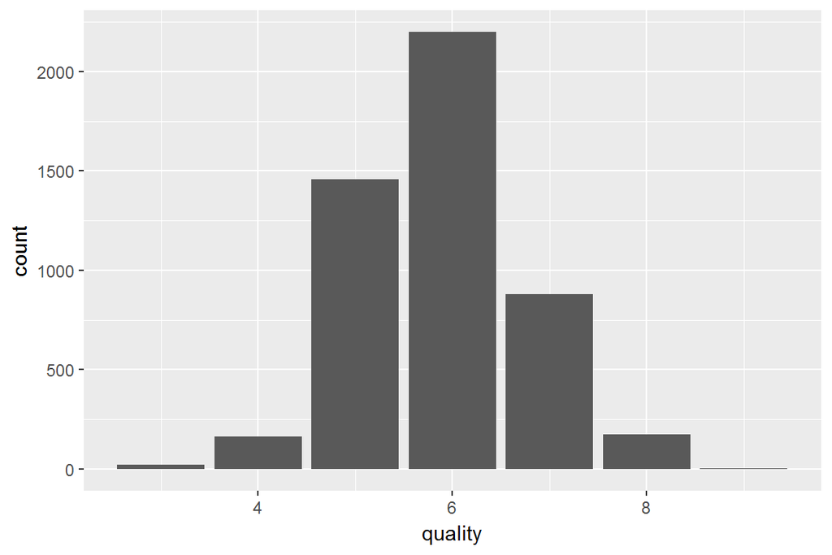

The variance of the quality distribution:

```
## [1] 0.7843557
```

The distribution is slightly left skewed with 6 as the mode. The mean is 5.88, and the variance is 0.78. Few are graded lower than 4 or greater than 8.

In this analysis, all the 11 physicochemical features may correlate with the quality. Before the correlation study, check the distribution of these features first.

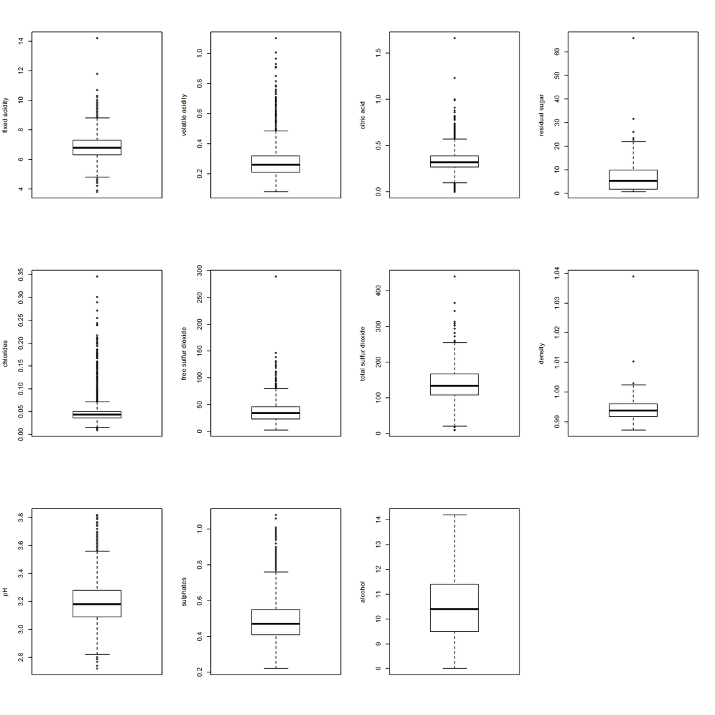

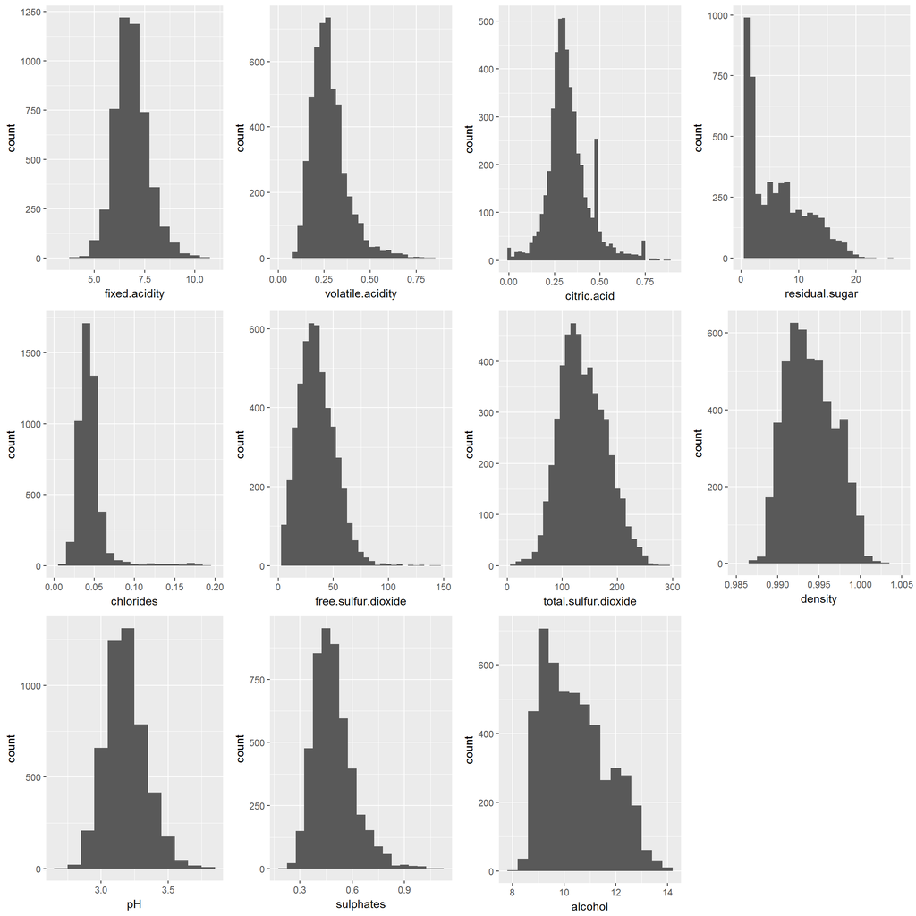

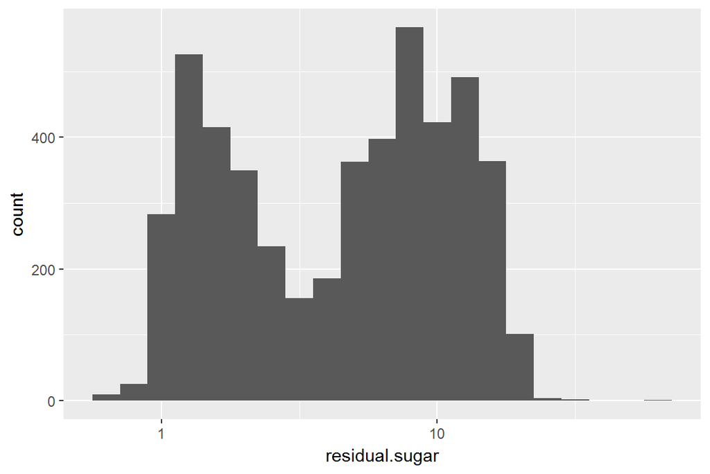

# Bivariate Plots Section

Check the correlation between these variables.

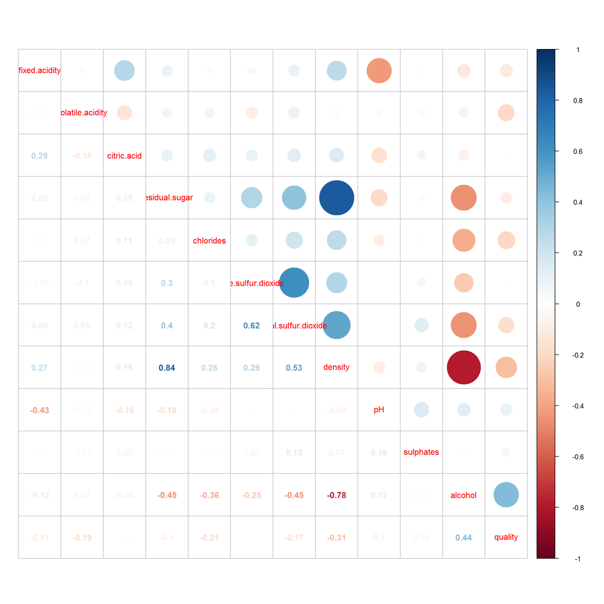

The residual sugar has a strong correlation of 0.84 with density, and the density has a strong negative correlation of -0.78 with alcohol. It seems as more sugar transformed into alcohol, the alcohol level increases. Meanwhile, more sugar transformed means less residual sugar, which leads to a lower density of the wine.

For the feature quality, it has a moderate positive correlation of 0.44 with alcohol, week negative correlation of -0.31 with density, -0.21 with chlorides, -0.19 with volatile acidity, -0.17 with total sulfur dioxide. The relationship between these features and quality will be checked.

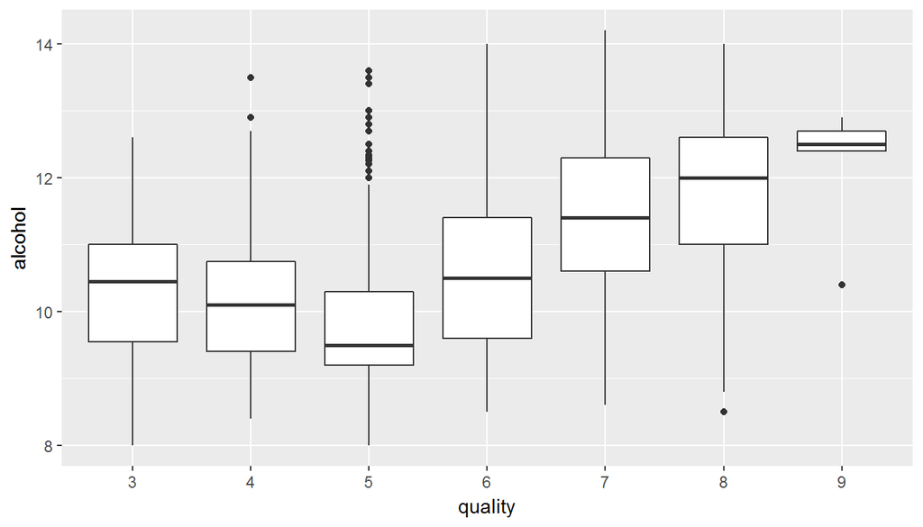

There is a tendency that higher quality wine has higher level of alcohol.

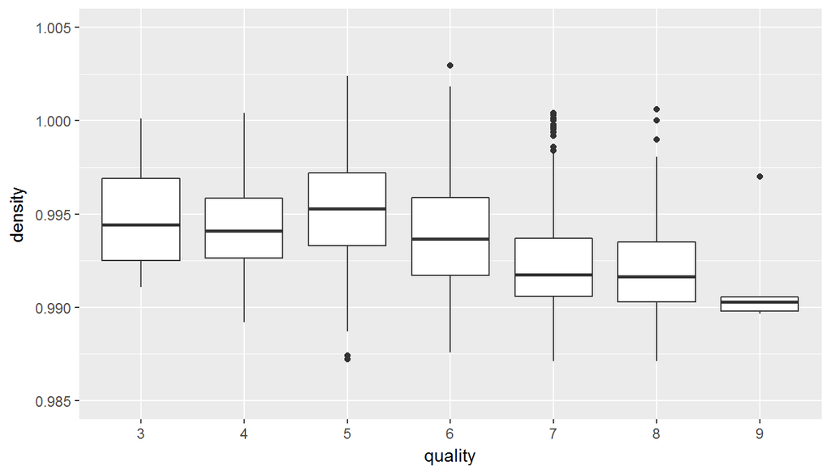

High quality wine tends to have lower density. This agrees with result from previous plot, because density has a strong negative correlation of -0.78 with alcohol.

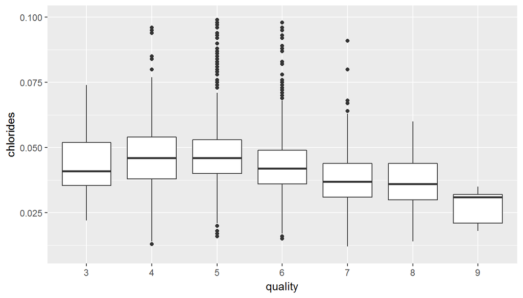

Higher quality wine tends to have a lower level of chlorides, and less spread in distribution.

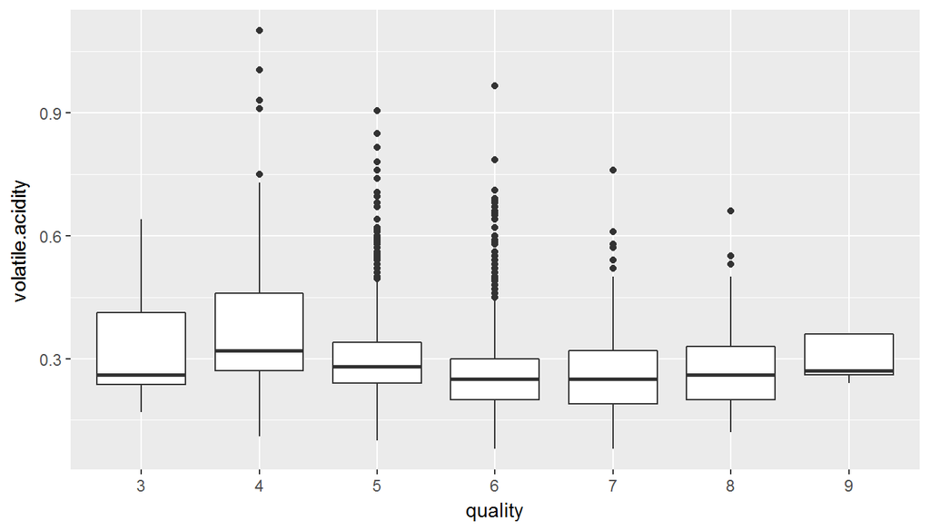

No clear trend is seen between volatile acidity and quality from this plot.

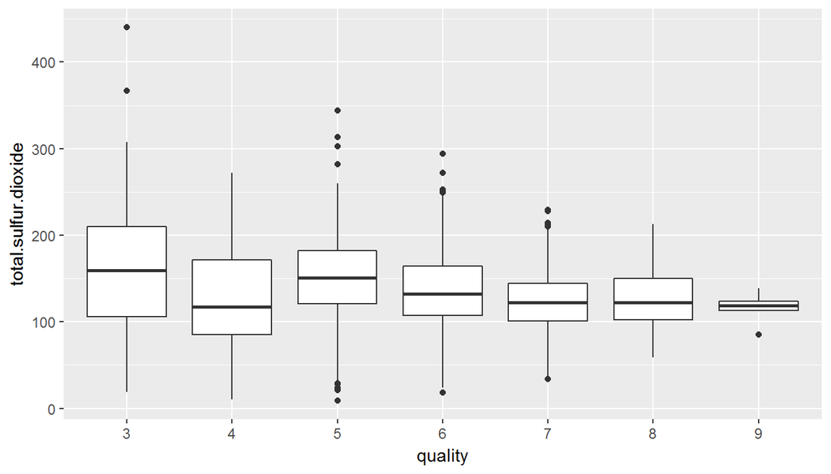

No clear trend is seen between total sulfur dioxide and quality from this plot.

# Multivariate Plots Section

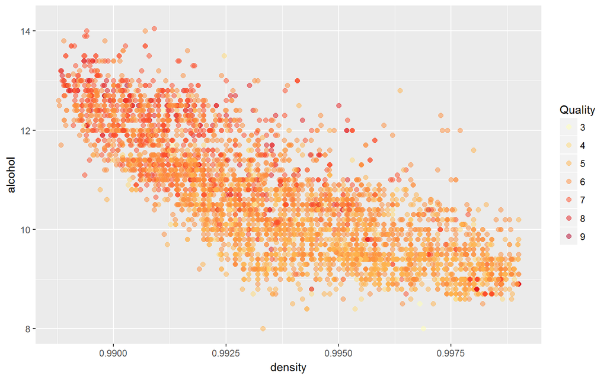

From the plot, high quality white wine tends to have higher alcohol and lower density. However, alcohol and density are strongly negative correlated, which explains for the result.

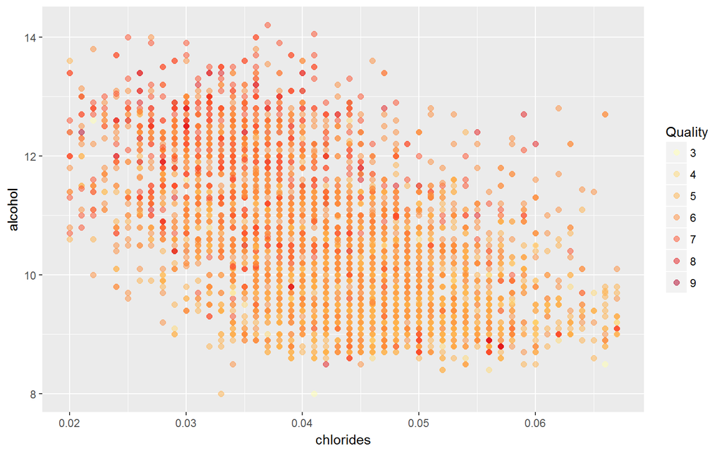

From the plot, high quality white wine tends to have higher alcohol and lower chlorides.

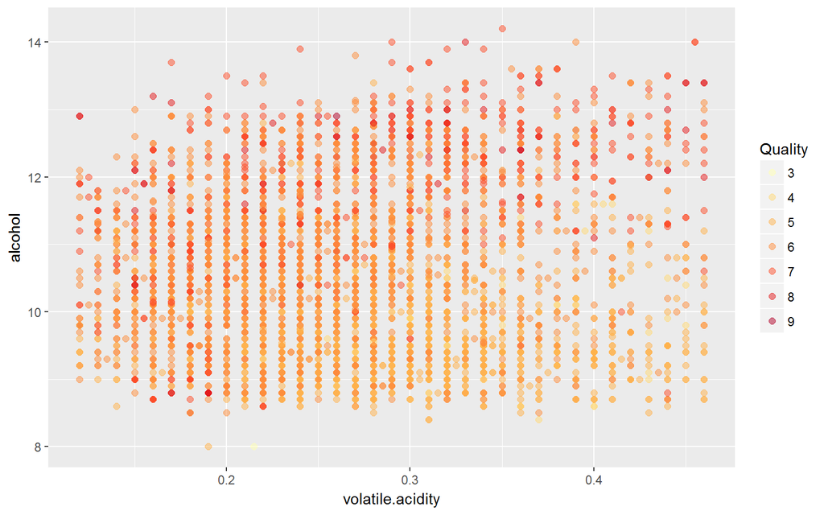

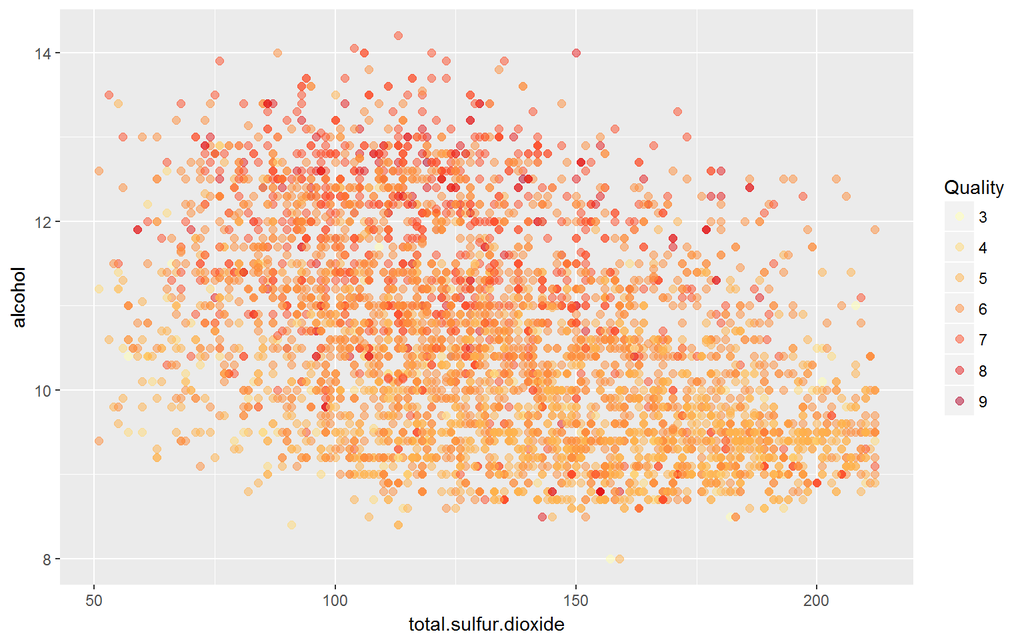

From the plot, higher quality wine tends to have a lower level of total sulfur dioxide and higher alcohol.

# Final Plots and Summary

### Plot One

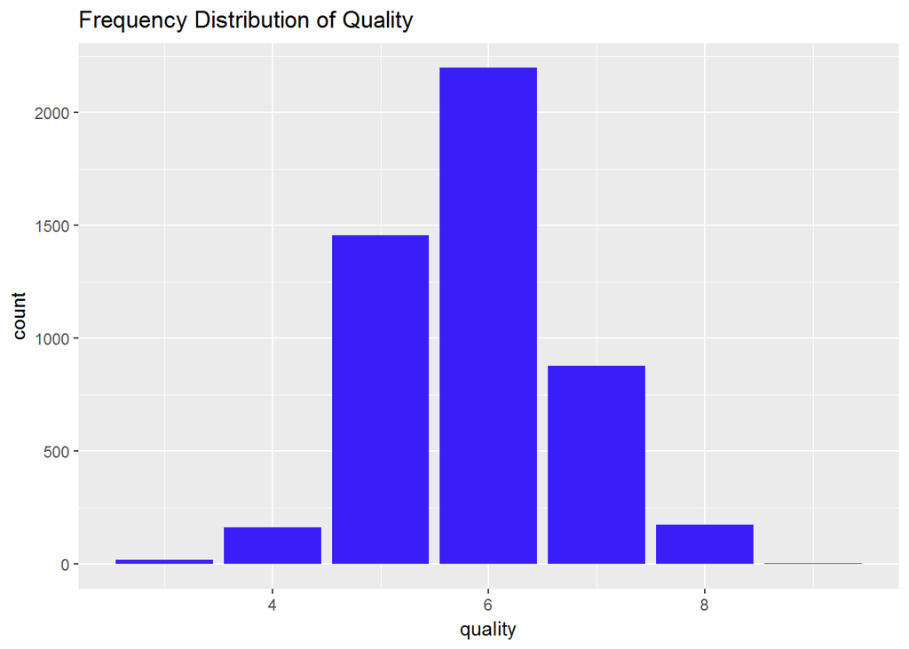

### Description One

The distribution is slightly left skewed. Most of the white wines are graded with 5 or 6. Few are graded lower than 4 or greater than 8. Among the 4898 observations, only 5 observation for grade 9 and 20 observation for grade 3. Because the quality is determined by the median of grade by at least 3 wine experts, it’s likely that different experts have different opinion on judging the quality of the win. So it makes sense that extremely high or low values are rare.

### Plot Two

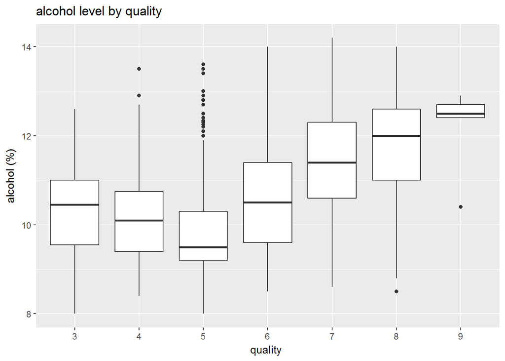

### Description Two

Alcohol has a moderate positive correlation of 0.44 with quality, which is the largest correlation with quality found among the features. The boxplot shows the alcohol percentage distribution for each quality. There is a tendency that higher quality wine has higher level of alcohol. Of course, more alcohol doesn’t necessarily mean higher quality wine. Many factors may explain this tendency. It’s possible that higher alcohol are the result of better quality grapes and better fermentation.

### Plot Three

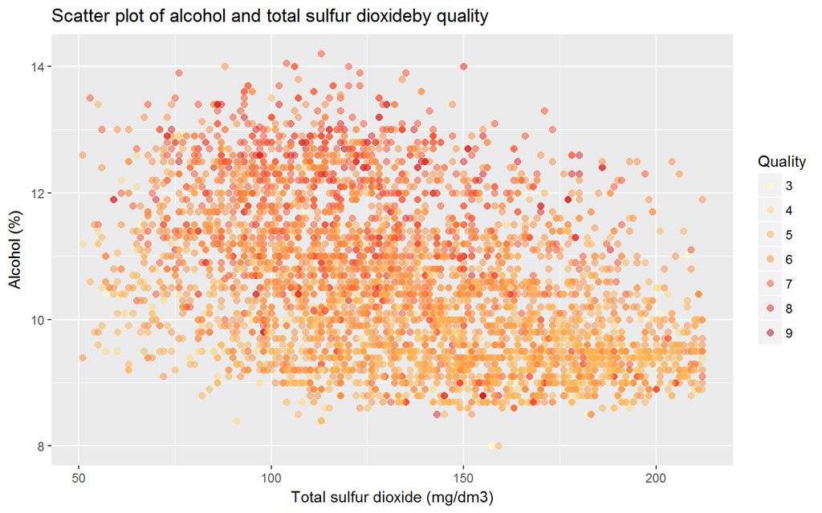

### Description Three

In the scatter plot of total sulfur dioxide and alcoholm, the quality are differentiate by color. Most of the light circles(wine with quality 5) converge at the right bottom of the plot. Low quality wine tends to have a higher level of total sulfur dioxide and lower alcohol. While most of the dark circles (quality 7,8) have higher level of alcohol and total sulfur dioxide less than 150 mg/dm3.

# Reflection

In this analysis, the correlation between white wine quality and 11 physicochemical features are studied using a dataset of 4898 observations. It’s found that alcohol has a moderate positive correlation with quality, while density, chloride, volative acidity and total sulfur dioxide have low negative correlation with wine quality. However, it’s hard to tell what physicochemical features a good white wine should have. There is no obvious liner relationship between these factors, further study may need the tools of machine learning to train a model to dig out the complicated relationships. Also, the samples for high(>8) and low quality(<4) wine would be important for study, but the statistics is not enough in the dataset.